# Spring 2026 PUBH 422 Project 2 Group 6

2026-04-17

# NHIS 2021 Data Analysis Group Project

### Group 6 Members: Abril Zarate, Andrew Carias, Nancy Hernandez, Brianna Ricard

## Environment Setup & Data Import

```r
# Task 2:Perform an initial exploration}
library(tidyverse)
NHIS_Data_2021 <- read_csv("data/NHIS _Data_2021.csv")
str(NHIS_Data_2021)
```

```
## spc_tbl_ [29,482 × 18] (S3: spec_tbl_df/tbl_df/tbl/data.frame)
##  $ DEMENEV_A   : num [1:29482] 2 2 2 2 2 2 2 2 2 2 ...
##  $ COPDEV_A    : num [1:29482] 2 2 2 2 2 2 2 2 2 2 ...
##  $ HYPEV_A     : num [1:29482] 1 1 2 1 2 1 2 2 2 2 ...
##  $ DEPEV_A     : num [1:29482] 2 2 2 2 2 2 2 2 2 1 ...
##  $ CANEV_A     : num [1:29482] 2 2 2 2 2 2 2 2 2 2 ...
##  $ DIBEV_A     : num [1:29482] 2 1 2 2 2 2 2 2 2 2 ...
##  $ AGEP_A      : num [1:29482] 50 53 56 57 25 55 45 41 26 71 ...
##  $ SEX_A       : num [1:29482] 1 1 1 2 1 1 1 1 2 2 ...
##  $ HISPALLP_A  : num [1:29482] 2 3 2 2 3 3 2 3 3 2 ...
##  $ MARSTAT_A   : num [1:29482] 5 6 5 7 9 9 1 1 7 1 ...
##  $ EDUCP_A     : num [1:29482] 1 7 8 5 4 5 9 5 4 9 ...
##  $ PHSTAT_A    : num [1:29482] 2 2 2 4 3 3 1 1 2 1 ...
##  $ LSATIS4R_A  : num [1:29482] 2 1 3 2 8 8 1 1 1 1 ...
##  $ SMKCIGST_A  : num [1:29482] 3 4 3 3 9 9 4 4 4 4 ...
##  $ RATCAT_A    : num [1:29482] 7 12 14 11 6 6 14 14 7 14 ...
##  $ BMICAT_A    : num [1:29482] 3 3 3 4 4 3 9 3 4 2 ...
##  $ WEIGHTLBTC_A: num [1:29482] 199 205 160 190 250 200 997 206 996 127 ...
##  $ HEIGHTTC_A  : num [1:29482] 69 75 67 63 72 69 67 72 96 63 ...
##  - attr(*, "spec")=
##   .. cols(
##   ..   DEMENEV_A = col_double(),
##   ..   COPDEV_A = col_double(),
##   ..   HYPEV_A = col_double(),
##   ..   DEPEV_A = col_double(),
##   ..   CANEV_A = col_double(),
##   ..   DIBEV_A = col_double(),
##   ..   AGEP_A = col_double(),
##   ..   SEX_A = col_double(),
##   ..   HISPALLP_A = col_double(),
##   ..   MARSTAT_A = col_double(),
##   ..   EDUCP_A = col_double(),
##   ..   PHSTAT_A = col_double(),
##   ..   LSATIS4R_A = col_double(),
##   ..   SMKCIGST_A = col_double(),
##   ..   RATCAT_A = col_double(),
##   ..   BMICAT_A = col_double(),
##   ..   WEIGHTLBTC_A = col_double(),
##   ..   HEIGHTTC_A = col_double()
##   .. )
##  - attr(*, "problems")=<externalptr>
```

```r
summary(NHIS_Data_2021)
```

```
##    DEMENEV_A        COPDEV_A        HYPEV_A         DEPEV_A
##  Min.   :1.000   Min.   :1.000   Min.   :1.000   Min.   :1.000
##  1st Qu.:2.000   1st Qu.:2.000   1st Qu.:1.000   1st Qu.:2.000
##  Median :2.000   Median :2.000   Median :2.000   Median :2.000
##  Mean   :1.993   Mean   :1.951   Mean   :1.648   Mean   :1.829
##  3rd Qu.:2.000   3rd Qu.:2.000   3rd Qu.:2.000   3rd Qu.:2.000
##  Max.   :9.000   Max.   :9.000   Max.   :9.000   Max.   :9.000
##     CANEV_A         DIBEV_A        AGEP_A          SEX_A         HISPALLP_A
##  Min.   :1.000   Min.   :1.0   Min.   :18.00   Min.   :1.000   Min.   :1.000
##  1st Qu.:2.000   1st Qu.:2.0   1st Qu.:37.00   1st Qu.:1.000   1st Qu.:2.000
##  Median :2.000   Median :2.0   Median :53.00   Median :2.000   Median :2.000
##  Mean   :1.882   Mean   :1.9   Mean   :52.63   Mean   :1.547   Mean   :2.203
##  3rd Qu.:2.000   3rd Qu.:2.0   3rd Qu.:68.00   3rd Qu.:2.000   3rd Qu.:2.000
##  Max.   :9.000   Max.   :9.0   Max.   :99.00   Max.   :9.000   Max.   :7.000
##    MARSTAT_A        EDUCP_A          PHSTAT_A      LSATIS4R_A
##  Min.   :1.000   Min.   : 1.000   Min.   :1.00   Min.   :1.000
##  1st Qu.:1.000   1st Qu.: 4.000   1st Qu.:2.00   1st Qu.:1.000
##  Median :4.000   Median : 6.000   Median :2.00   Median :2.000
##  Mean   :3.858   Mean   : 6.447   Mean   :2.39   Mean   :1.748
##  3rd Qu.:7.000   3rd Qu.: 8.000   3rd Qu.:3.00   3rd Qu.:2.000
##  Max.   :9.000   Max.   :99.000   Max.   :9.00   Max.   :9.000
##    SMKCIGST_A       RATCAT_A         BMICAT_A      WEIGHTLBTC_A
##  Min.   :1.000   Min.   : 1.000   Min.   :1.000   Min.   :100.0
##  1st Qu.:3.000   1st Qu.: 7.000   1st Qu.:2.000   1st Qu.:150.0
##  Median :4.000   Median :11.000   Median :3.000   Median :180.0
##  Mean   :3.579   Mean   : 9.848   Mean   :3.121   Mean   :248.8
##  3rd Qu.:4.000   3rd Qu.:14.000   3rd Qu.:4.000   3rd Qu.:215.0
##  Max.   :9.000   Max.   :14.000   Max.   :9.000   Max.   :999.0
##    HEIGHTTC_A
##  Min.   :59.00
##  1st Qu.:64.00
##  Median :67.00
##  Mean   :68.72
##  3rd Qu.:70.00
##  Max.   :99.00
```

```r
head(NHIS_Data_2021)
```

```
## # A tibble: 6 × 18
##   DEMENEV_A COPDEV_A HYPEV_A DEPEV_A CANEV_A DIBEV_A AGEP_A SEX_A HISPALLP_A
##       <dbl>    <dbl>   <dbl>   <dbl>   <dbl>   <dbl>  <dbl> <dbl>      <dbl>
## 1         2        2       1       2       2       2     50     1          2
## 2         2        2       1       2       2       1     53     1          3
## 3         2        2       2       2       2       2     56     1          2
## 4         2        2       1       2       2       2     57     2          2
## 5         2        2       2       2       2       2     25     1          3
## 6         2        2       1       2       2       2     55     1          3
## # ℹ 9 more variables: MARSTAT_A <dbl>, EDUCP_A <dbl>, PHSTAT_A <dbl>,
## #   LSATIS4R_A <dbl>, SMKCIGST_A <dbl>, RATCAT_A <dbl>, BMICAT_A <dbl>,
## #   WEIGHTLBTC_A <dbl>, HEIGHTTC_A <dbl>
```

Interpretation: The 2021 NHIS data consisted of 29,482 observations and 18 variables.

## Variable Selection, Missing Value Check & Recoding Variables

```r
# Day 2: Task 1 - Variable Selection & Missing Value Check}

library(tidyverse)

NHIS_Data_2021 <- read_csv("data/NHIS _Data_2021.csv")
# Select only variables asked for
data_import_R_02_subset <- NHIS_Data_2021 |>
  select(
    AGEP_A,
    WEIGHTLBTC_A,
    HEIGHTTC_A,
    SEX_A,
    HISPALLP_A,
    EDUCP_A,
    PHSTAT_A,
    LSATIS4R_A
  )
View(data_import_R_02_subset)

# Remove missing / nonresponse values using variable-specific codebook values
clean_data_R_02 <- data_import_R_02_subset |>
  filter(
    !AGEP_A %in% c(97, 98, 99),
    !SEX_A %in% c(7, 9),
    !HISPALLP_A %in% c(97, 98, 99),
    !EDUCP_A %in% c(97, 98, 99),
    !PHSTAT_A %in% c(7, 8, 9),
    !LSATIS4R_A %in% c(7, 8, 9),
    !WEIGHTLBTC_A %in% c(996, 997, 998, 999),
    !HEIGHTTC_A %in% c(96, 97, 98, 99)
  )
View(clean_data_R_02) # check

# Check cleaned data
summary(clean_data_R_02)
```

```
##      AGEP_A       WEIGHTLBTC_A     HEIGHTTC_A       SEX_A        HISPALLP_A
##  Min.   :18.00   Min.   :100.0   Min.   :59.0   Min.   :1.00   Min.   :1.000
##  1st Qu.:37.00   1st Qu.:147.0   1st Qu.:64.0   1st Qu.:1.00   1st Qu.:2.000
##  Median :54.00   Median :173.0   Median :66.0   Median :2.00   Median :2.000
##  Mean   :52.57   Mean   :176.8   Mean   :66.7   Mean   :1.54   Mean   :2.197
##  3rd Qu.:67.00   3rd Qu.:200.0   3rd Qu.:70.0   3rd Qu.:2.00   3rd Qu.:2.000
##  Max.   :85.00   Max.   :299.0   Max.   :76.0   Max.   :2.00   Max.   :7.000
##     EDUCP_A          PHSTAT_A       LSATIS4R_A
##  Min.   : 1.000   Min.   :1.000   Min.   :1.000
##  1st Qu.: 4.000   1st Qu.:2.000   1st Qu.:1.000
##  Median : 6.000   Median :2.000   Median :2.000
##  Mean   : 6.032   Mean   :2.346   Mean   :1.583
##  3rd Qu.: 8.000   3rd Qu.:3.000   3rd Qu.:2.000
##  Max.   :10.000   Max.   :5.000   Max.   :4.000
```

```r
sum(is.na(clean_data_R_02))
```

```
## [1] 0
```

```r
# Day 2: Task 2 - Recoding Variables

clean_data_R_02 <- clean_data_R_02 %>%
  mutate(
    EDUCP_A = case_when(
      EDUCP_A >= 0 & EDUCP_A <= 3 ~ 1,
      EDUCP_A == 4 ~ 2,
      EDUCP_A >= 5 & EDUCP_A <= 7 ~ 3,
      EDUCP_A >= 8 & EDUCP_A <= 10 ~ 4
    ),
    EDUCP_A = factor(
      EDUCP_A,
      levels = c(1, 2, 3, 4),
      labels = c(
        "Less than High School",
        "High School Graduate",
        "Some College Education",
        "College Graduate or Better"
      )
    )
  )

# Verify recoding
summary(clean_data_R_02)
```

```
##      AGEP_A       WEIGHTLBTC_A     HEIGHTTC_A       SEX_A        HISPALLP_A
##  Min.   :18.00   Min.   :100.0   Min.   :59.0   Min.   :1.00   Min.   :1.000
##  1st Qu.:37.00   1st Qu.:147.0   1st Qu.:64.0   1st Qu.:1.00   1st Qu.:2.000
##  Median :54.00   Median :173.0   Median :66.0   Median :2.00   Median :2.000
##  Mean   :52.57   Mean   :176.8   Mean   :66.7   Mean   :1.54   Mean   :2.197
##  3rd Qu.:67.00   3rd Qu.:200.0   3rd Qu.:70.0   3rd Qu.:2.00   3rd Qu.:2.000
##  Max.   :85.00   Max.   :299.0   Max.   :76.0   Max.   :2.00   Max.   :7.000
##                        EDUCP_A         PHSTAT_A       LSATIS4R_A
##  Less than High School     : 2676   Min.   :1.000   Min.   :1.000
##  High School Graduate      : 5765   1st Qu.:2.000   1st Qu.:1.000
##  Some College Education    : 7238   Median :2.000   Median :2.000
##  College Graduate or Better:10358   Mean   :2.346   Mean   :1.583
##                                     3rd Qu.:3.000   3rd Qu.:2.000
##                                     Max.   :5.000   Max.   :4.000
```

```r
table(clean_data_R_02$EDUCP_A)
```

```
##
##      Less than High School       High School Graduate
##                       2676                       5765
##     Some College Education College Graduate or Better
##                       7238                      10358
```

```r
write_csv(clean_data_R_02, "data/nhis_clean.csv")
```

Interpretation: After the selected variables were extracted, removals of missing/nonresponsive answers, and recoding the Education variable, the data consisted of 26,037 observations and 8 variables.

## Univariate Analysis

### Quantitative Variable: **Age Summary Statistics & Histogram**

```r
# Day 3: Task 1: Univariate Analysis & Visualization}

library(tidyverse) #loading tidyverse package
library(fBasics)

nhis_clean <- read_csv("data/nhis_clean.csv") #loading nhis_clean data into R
"Quantitative Variables"
```

```
## [1] "Quantitative Variables"
```

```r
#AgeP_A (Age)
summary(nhis_clean$AGEP_A) #summary stats for age
```

```
##    Min. 1st Qu.  Median    Mean 3rd Qu.    Max.
##   18.00   37.00   54.00   52.57   67.00   85.00
```

```r
sd(nhis_clean$AGEP_A) #standard deviation for age
```

```
## [1] 18.33484
```

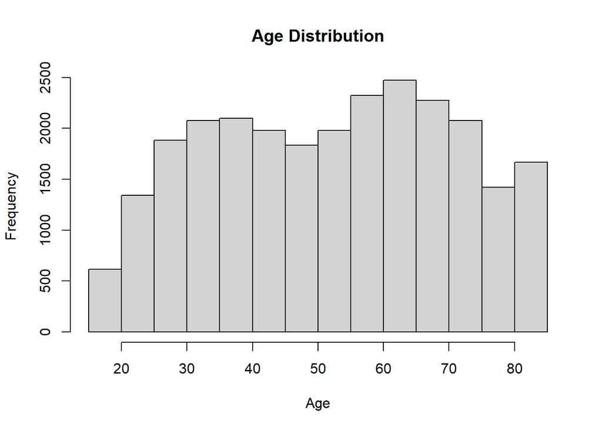

```r
#Base histogram AGEP_A
hist(nhis_clean$AGEP_A, main = "Age Distribution",xlab="Age")
```

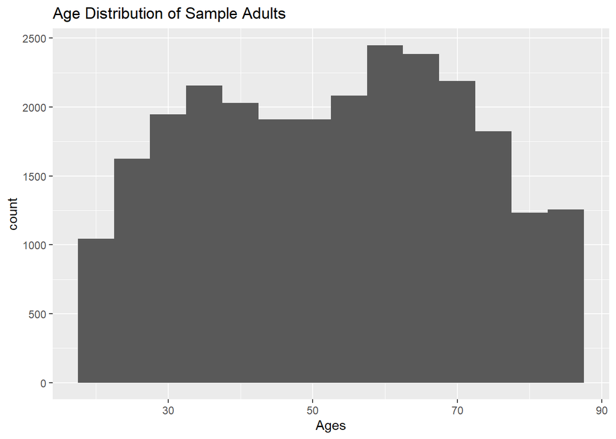

```r
#ggplot histogram AGEP_A
ggplot(nhis_clean,aes(x=AGEP_A)) + #x axis will be Age
  geom_histogram(binwidth = 5) + #data will be distributed among 5 bins
  xlab("Ages") + #x axis title
  ggtitle("Age Distribution of Sample Adults") #chart title
```

Interpretation: The age distribution spans from approximately 18 to 80 years which demonstrates a wide range of ages in the sample. The graph shows a higher concentration of individuals in the middle-to-older age groups, mainly between 50-70 years with a peak around early 60s. Overall, the distribution demonstrates considerable variability with a small tendency toward older ages.

### Quantitative Variable: **Age Boxplot**

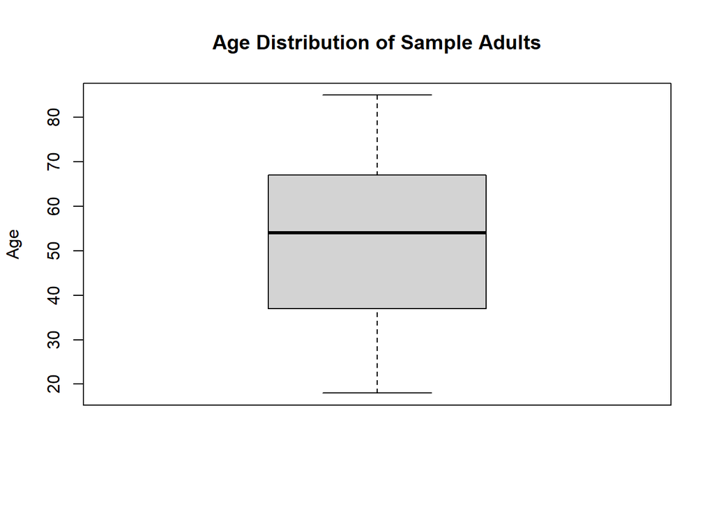

```r
#Base boxplot of AGEP_A
boxplot(nhis_clean$AGEP_A, main = "Age Distribution of Sample Adults", ylab="Age")
```

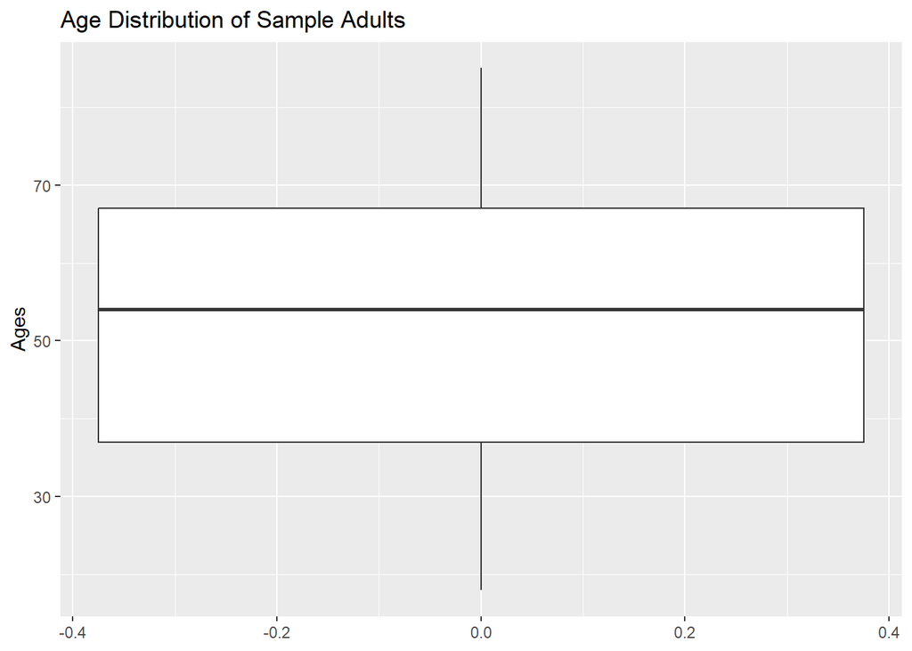

```r
#ggplot boxplot of AGEP_A
ggplot(nhis_clean, aes(y=AGEP_A)) + #y axis will be age values
  geom_boxplot() + #identifying boxplot
  ggtitle("Age Distribution of Sample Adults") + #chart title
  ylab("Ages") #y axis title
```

Interpretation: The boxplots demonstrate that the median age of participants is around mid-50s, resulting in a relatively older sample. The overall age range spans from slightly below 20 to around 80 years of age. The distribution appears slightly left-skewed, with a somewhat greater spread among older ages and no significant outliers are observed.

### Quantitative Variable: **Weight Summary Statistics & Histogram**

```r
#WEIGHTLBTC_A (Weight w/out shoes)
summary(nhis_clean$WEIGHTLBTC_A) #Summary stat for weight w/o shoes
```

```
##    Min. 1st Qu.  Median    Mean 3rd Qu.    Max.
##   100.0   147.0   173.0   176.8   200.0   299.0
```

```r
sd(nhis_clean$WEIGHTLBTC_A) #standard dev for weight w/o shoes
```

```
## [1] 39.59538
```

```r
basicStats(nhis_clean$WEIGHTLBTC_A) #summary stat for weight w/o shoes
```

```
##             X..nhis_clean.WEIGHTLBTC_A
## nobs                      2.603700e+04
## NAs                       0.000000e+00
## Minimum                   1.000000e+02
## Maximum                   2.990000e+02
## 1. Quartile               1.470000e+02
## 3. Quartile               2.000000e+02
## Mean                      1.768261e+02
## Median                    1.730000e+02
## Sum                       4.604021e+06
## SE Mean                   2.453860e-01
## LCL Mean                  1.763451e+02
## UCL Mean                  1.773071e+02
## Variance                  1.567794e+03
## Stdev                     3.959538e+01
## Skewness                  4.708550e-01
## Kurtosis                 -2.602220e-01
```

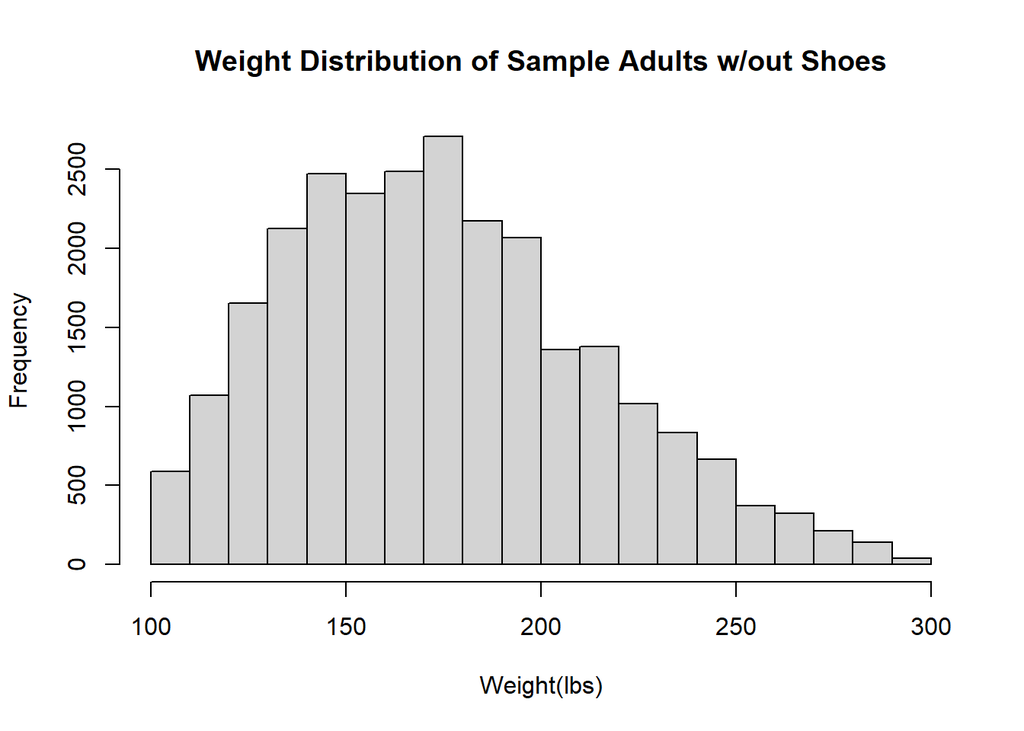

```r
#Base histogram WEIGHTLBTC_A
hist(nhis_clean$WEIGHTLBTC_A, main = "Weight Distribution of Sample Adults w/out Shoes",xlab="Weight(lbs)")
```

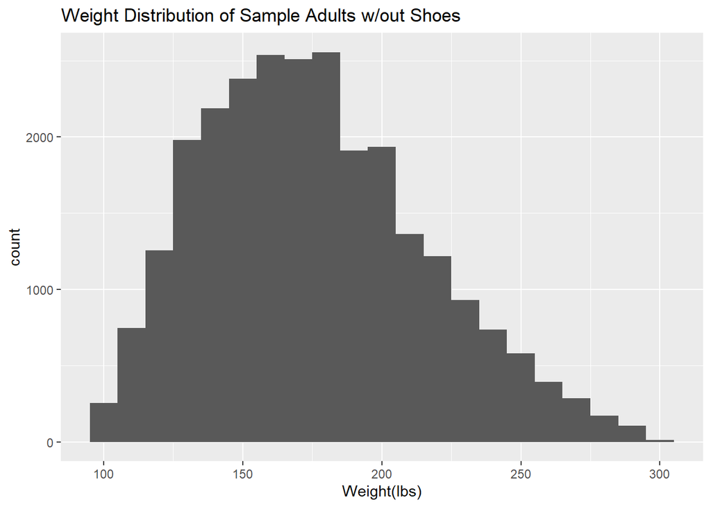

```r
#ggplot histogram WEIGHTLBTC_A
ggplot(nhis_clean,aes(x=WEIGHTLBTC_A)) + #x axis will be weight
  geom_histogram(binwidth = 10) + #data will be distributed among 10 bins
  xlab("Weight(lbs)") + #x axis title
  ggtitle("Weight Distribution of Sample Adults w/out Shoes") #chart title
```

Interpretation: The weight distribution ranges from approximately 100 to around 300 pounds, indicating a wide range of weights in the sample. The graph shows a positive skew, with a higher concentration of individuals weighing 130 to 200 pounds, mainly 140 to 190, peaking at 170. Overall, the distribution shows considerable variability with slight outliers.

### Quantitative Variable: **Weight Boxplot**

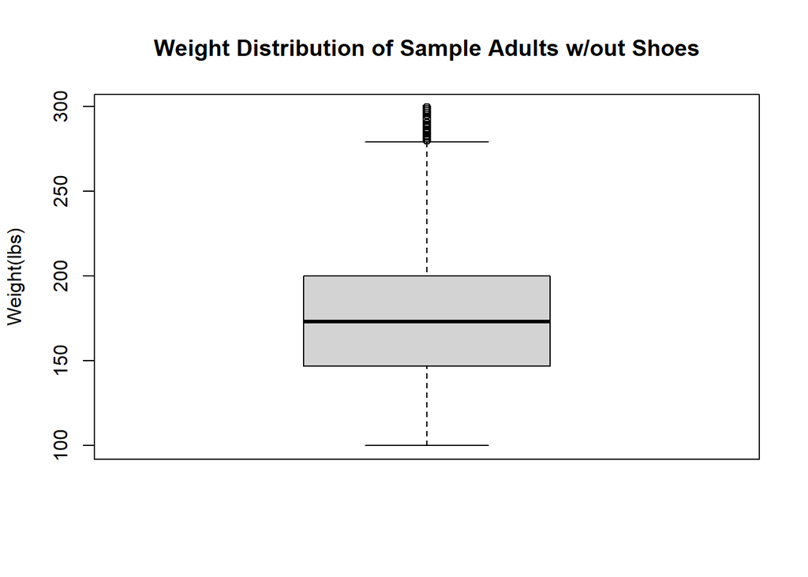

```r
#Base boxplot of WEIGHTLBTC_A
boxplot(nhis_clean$WEIGHTLBTC_A, main = "Weight Distribution of Sample Adults w/out Shoes",ylab = "Weight(lbs)")
```

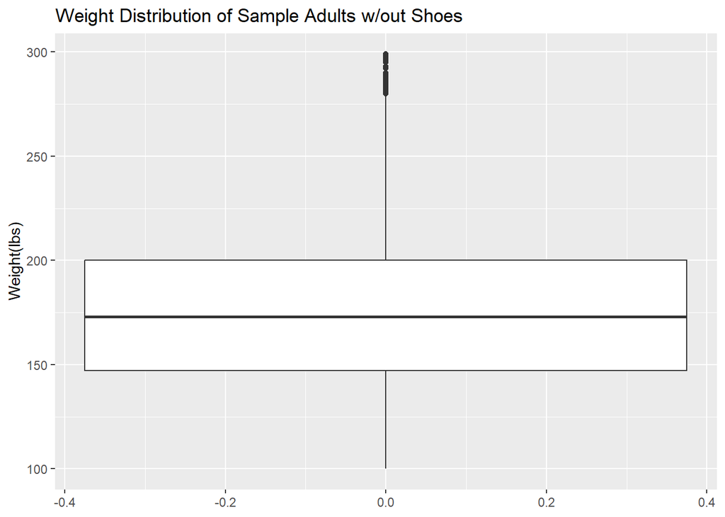

```r
#ggplot boxplot of WEIGHTLBTC_A
ggplot(nhis_clean, aes(y=WEIGHTLBTC_A)) + #y axis will be weight values
  geom_boxplot() + #identidying boxplot
  ggtitle("Weight Distribution of Sample Adults w/out Shoes") + #chart title
  ylab("Weight(lbs)") #y axis title
```

### Quantitative Variable: **Height Summary Statistics & Histogram**

```r
#HEIGHTTTC_A (Heigh in Inches)
basicStats(nhis_clean$HEIGHTTC_A) #summary stat for total height in inches
```

```
##             X..nhis_clean.HEIGHTTC_A
## nobs                    2.603700e+04
## NAs                     0.000000e+00
## Minimum                 5.900000e+01
## Maximum                 7.600000e+01
## 1. Quartile             6.400000e+01
## 3. Quartile             7.000000e+01
## Mean                    6.670108e+01
## Median                  6.600000e+01
## Sum                     1.736696e+06
## SE Mean                 2.416200e-02
## LCL Mean                6.665372e+01
## UCL Mean                6.674844e+01
## Variance                1.520059e+01
## Stdev                   3.898793e+00
## Skewness                1.719930e-01
## Kurtosis               -7.452840e-01
```

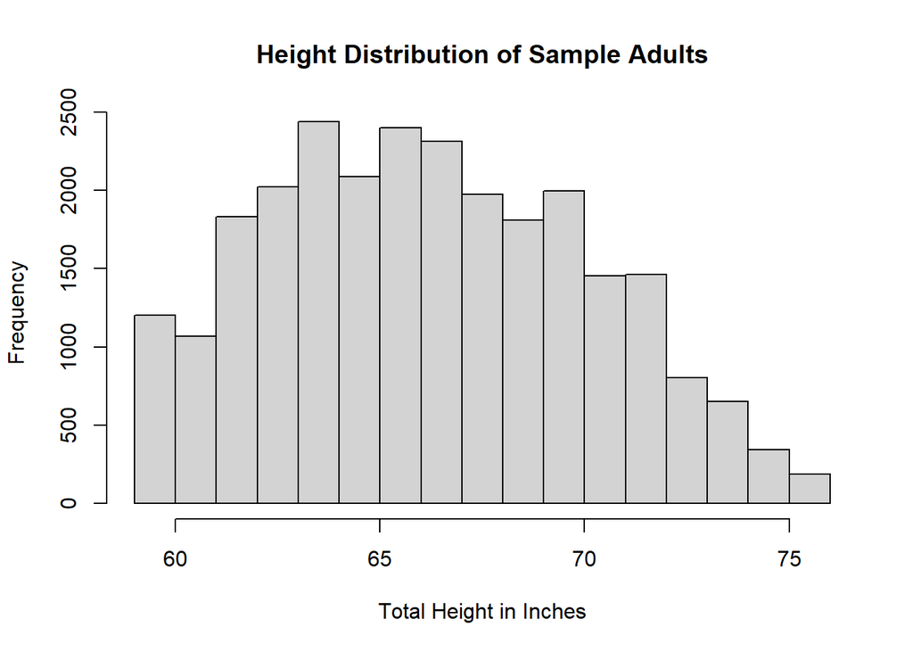

```r
#Base histogram HEIGHTTTC_A
hist(nhis_clean$HEIGHTTC_A, main = "Height Distribution of Sample Adults",xlab="Total Height in Inches")
```

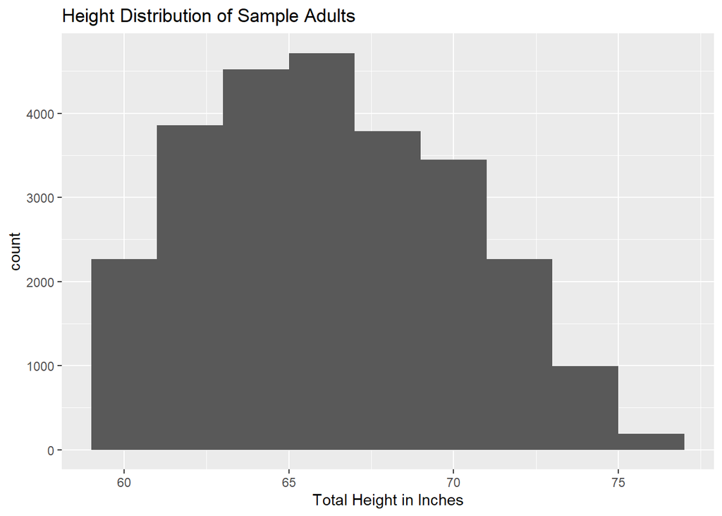

```r
#ggplot histogram HEIGHTTTC_A
ggplot(nhis_clean,aes(x=HEIGHTTC_A)) + #x axis will be total height in inches
  geom_histogram(binwidth = 2) + #data will be distributed among 2 bins
  xlab("Total Height in Inches") + #x axis title
  ggtitle("Height Distribution of Sample Adults") #chart title
```

Interpretation: The height distribution ranges from approximately 60 to about 75 inches, indicating substantial variability in the sample. The graph shows a higher concentration of individuals measuring 62 to 70 inches, with a peak at 63 inches. Overall, the distribution is slightly skewed to the right, but it appears fairly balanced.

### Quantitative Variable: **Height Boxplot**

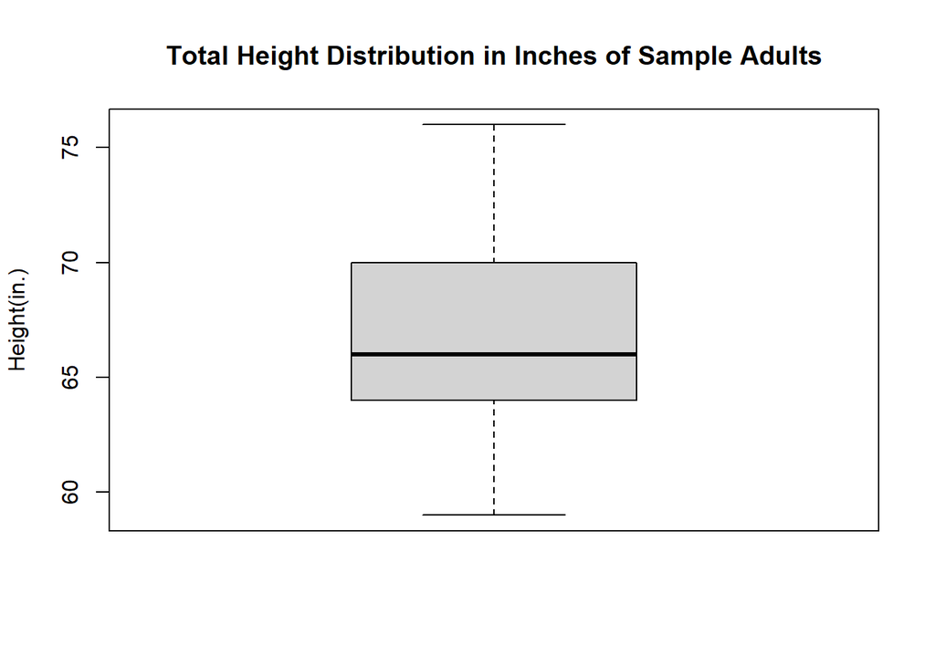

```r
#Base boxplot of HEIGHTTTC_A
boxplot(nhis_clean$HEIGHTTC_A, main="Total Height Distribution in Inches of Sample Adults",ylab = "Height(in.)")
```

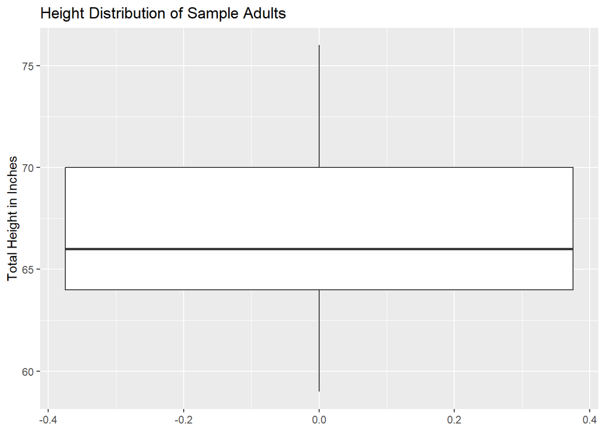

```r
#ggplot boxplot of HEIGHTTTC_A
ggplot(nhis_clean, aes(y=HEIGHTTC_A)) + #y axis will be height values
  geom_boxplot() + #identidying boxplot
  ggtitle("Height Distribution of Sample Adults") + #chart title
  ylab("Total Height in Inches") #y axis title
```

Interpretation: Overall, heights range from about 60 to about 75 inches, but most adults cluster between 65 and 70 inches. The boxplots show that the median height is about 66 inches, indicating this is the typical height in this sample. The median is slightly closer to the lower quartile, and the upper whisker is a bit longer, suggesting a mild right skew; however, the distribution looks fairly balanced overall.

### Qualitative Variable: **Sex Frequency Table & Barplot**

```r
"Qualitative Variables"
```

```
## [1] "Qualitative Variables"
```

```r
#SEX_A (Gender)

nhis_clean$SEX_A <- factor(nhis_clean$SEX_A, #creating categorical data to a factor
                           levels = c(1,2), #identifying the values w/in data
                           labels = c("Males","Females")) #relabeling the values w/corresponding label

sex_a_freq_table <- table(nhis_clean$SEX_A) #creating frequency table of sex_a variable

sex_a_freq_table #printing out the sex_a frequency table
```

```
##
##   Males Females
##   11967   14070
```

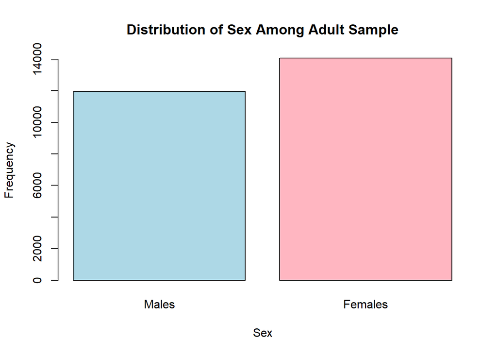

```r
barplot(sex_a_freq_table, #indicating r base barplot of sex_a variable through freq table
        main = "Distribution of Sex Among Adult Sample", #chart title
        xlab = "Sex", #x axis title
        ylab = "Frequency", #y axis title
        col = c("lightblue","lightpink")) #bar plot colors
```

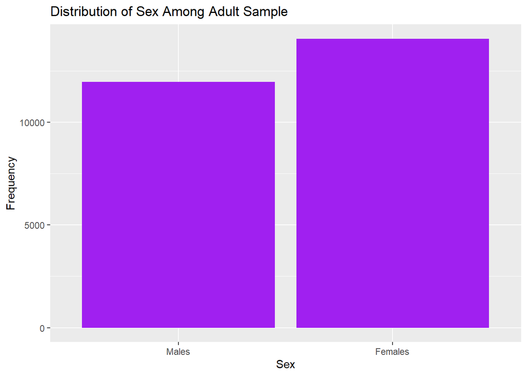

```r
sex_a_freq_df <- as.data.frame(sex_a_freq_table) #converting freq table to a data frame for ggplot

ggplot(sex_a_freq_df, aes(x=Var1,y=Freq)) + #using ggplot & the data frame, indicating x as the variables and y as the frequency
  geom_bar(stat = "identity",fill ="purple") + #indicating bar plot
  labs(title = "Distribution of Sex Among Adult Sample", #chart title
       x = "Sex", #x axis title
       y = "Frequency") #y axis title
```

Interpretation: The sample shows that there are more female participants than male participants, with 14,070 and 11,967, respectively.

### Qualitative Variable: **Race/Ethnicity Frequency Table & Barplot**

```r
#HISPALLP_A (Race/Ethnicity)

nhis_clean$HISPALLP_A <- factor(nhis_clean$HISPALLP_A, #creating categorical data to a factor
                           levels = c(1,2,3,4,5,6,7), #identifying the values w/in data
                           labels = c("Hispanic","NHWhite","NHAA","NHAsian Only","NHAIAN","NHAIAN&Other","Other")) #relabeling the values w/corresponding label

hispallp_a_freq_table <- table(nhis_clean$HISPALLP_A) #creating frequency table of HISPALLPa variable

hispallp_a_freq_table #printing out the hispallp_a frequency table
```

```
##
##     Hispanic      NHWhite         NHAA NHAsian Only       NHAIAN NHAIAN&Other
##         3533        17617         2645         1564          153          196
##        Other
##          329
```

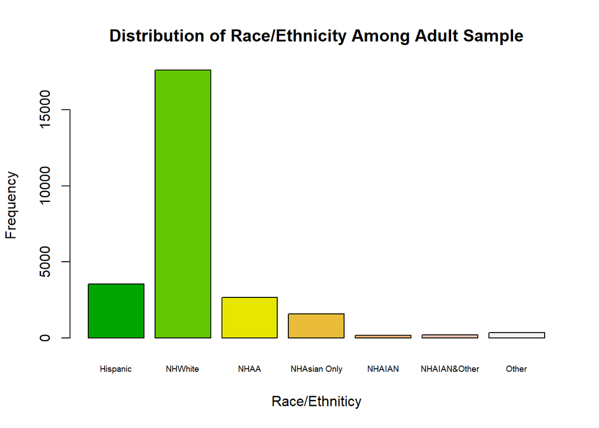

```r
barplot(hispallp_a_freq_table, #indicating r base barplot of hispallp_a variable through freq table
        main = "Distribution of Race/Ethnicity Among Adult Sample", #chart title
        xlab = "Race/Ethniticy", #x axis title
        ylab = "Frequency", #y axis title
        col = terrain.colors(7), #bar plot colors
        cex.names = 0.6) #label size
```

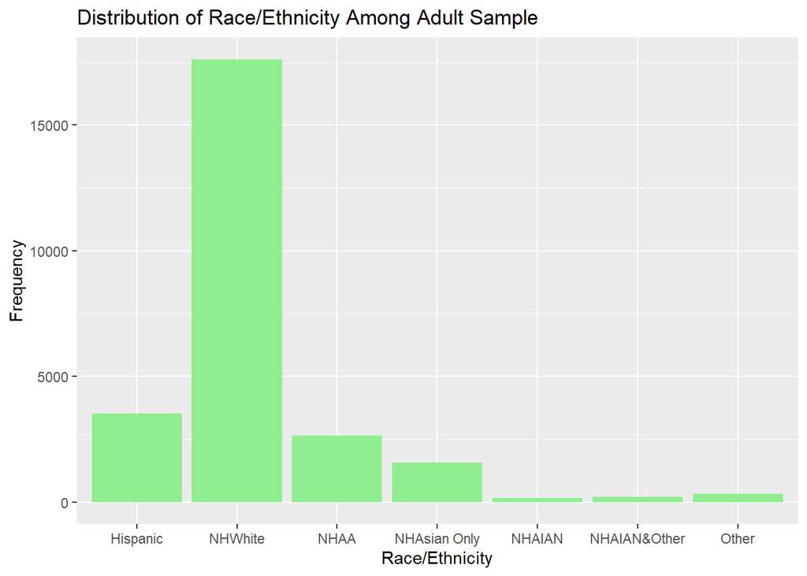

```r
hispallp_a_freq_df <- as.data.frame(hispallp_a_freq_table) #converting freq table to a data frame for ggplot

ggplot(hispallp_a_freq_df, aes(x=Var1,y=Freq)) + #using ggplot & the data frame, indicating x as the variables and y as the frequency
  geom_bar(stat = "identity",fill ="lightgreen") + #indicating bar plot
  labs(title = "Distribution of Race/Ethnicity Among Adult Sample", #chart title
       x = "Race/Ethnicity", #x axis title
       y = "Frequency") #y axis title
```

Interpretation: The sample consists mostly of Non-Hispanic White individuals, representing 17,617 of the sample. Hispanic participants were the second most represented in the sample, comprising 3,533 participants. Non-Hispanic African Americans and Non-Hispanic Asians had similar representation, with 2645 and 1564, respectively. Lastly, Non-Hispanic American Indian and Alaska Native, Non-Hispanic American Indian and Alaska Native and Other, and Other were the least represented in the sample.

### Qualitative Variable: **Education Frequency Table & Barplot**

```r
#EDUCP_A (Education Level)

"EDCUP_A was already recoded and turned into a factor in previous task"
```

```
## [1] "EDCUP_A was already recoded and turned into a factor in previous task"
```

```r
educp_a_freq_table <- table(nhis_clean$EDUCP_A) #creating frequency table of EDUCP_A variable

educp_a_freq_table #printing out the educp_a frequency table
```

```
##
## College Graduate or Better       High School Graduate
##                      10358                       5765
##      Less than High School     Some College Education
##                       2676                       7238
```

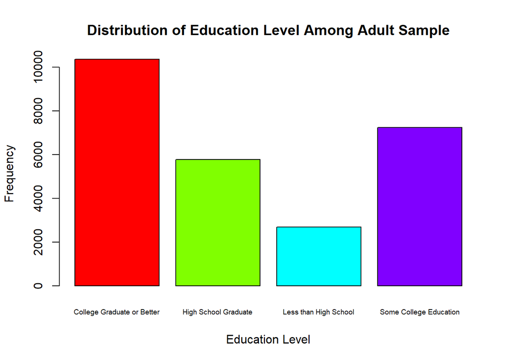

```r
barplot(educp_a_freq_table, #indicating r base barplot of educp_a variable through freq table
        main = "Distribution of Education Level Among Adult Sample", #chart title
        xlab = "Education Level", #x axis title
        ylab = "Frequency", #y axis title
        col = rainbow(4), #bar plot colors
        cex.names = 0.6) #label size
```

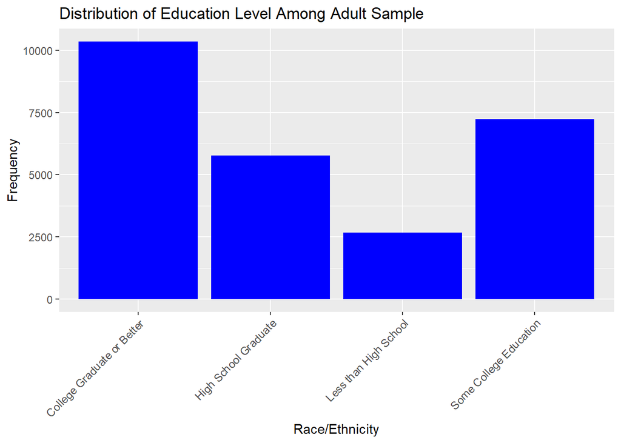

```r
educp_a_freq_df <- as.data.frame(educp_a_freq_table) #converting freq table to a data frame for ggplot

ggplot(educp_a_freq_df, aes(x=Var1,y=Freq)) + #using ggplot & the data frame, indicating x as the variables and y as the frequency
  geom_bar(stat = "identity",fill ="blue") + #indicating bar plot
  labs(title = "Distribution of Education Level Among Adult Sample", #chart title
       x = "Race/Ethnicity", #x axis title
       y = "Frequency") + #yaxis title
  theme(axis.text.x = element_text(size = 9, angle = 45, hjust = 1)) #adjusts labels on x axis
```

Interpretation: The majority of the participants are educated because most of the sample are college graduates or better, and the second most represented group obtained some college education. High school graduates were the third most represented group, and the least represented group had less than a high school education.

### Qualitative Variable: **General Health Status Frequency Table & Barplot**

```r
#PHSTAT_A (General Health)

nhis_clean$PHSTAT_A<- factor(nhis_clean$PHSTAT_A, #creating categorical data to a factor
                                levels = c(1,2,3,4,5), #identifying the values w/in data
                                labels = c("Excellent","Very Good","Good","Fair","Poor")) #relabeling the values w/corresponding label

phstat_a_freq_table <- table(nhis_clean$PHSTAT_A) #creating frequency table of PHSTAT_A variable

phstat_a_freq_table #printing out the phstat_a frequency table
```

```
##
## Excellent Very Good      Good      Fair      Poor
##      6065      9185      7287      2717       783
```

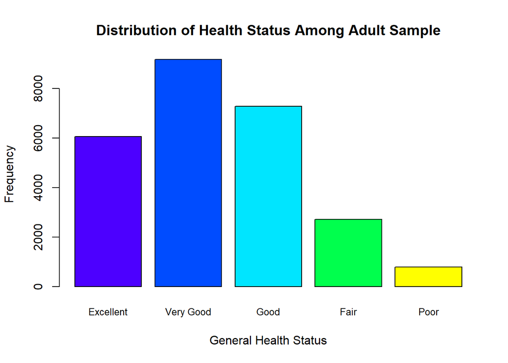

```r
barplot(phstat_a_freq_table, #indicating r base barplot of phstat_a variable through freq table
        main = "Distribution of Health Status Among Adult Sample", #chart title
        xlab = "General Health Status", #x axis title
        ylab = "Frequency", #y axis title
        col = topo.colors(5), #bar plot colors
        cex.names = 0.8) #label size
```

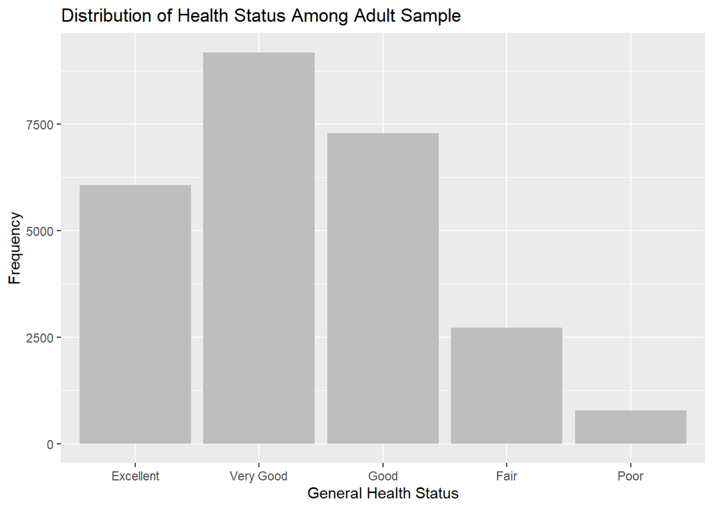

```r
phstat_a_freq_df <- as.data.frame(phstat_a_freq_table) #converting freq table to a data frame for ggplot

ggplot(phstat_a_freq_df, aes(x=Var1,y=Freq)) + #using ggplot & the data frame, indicating x as the variables and y as the frequency
  geom_bar(stat = "identity",fill ="gray") + #indicating bar plot
  labs(title = "Distribution of Health Status Among Adult Sample", #chart title
       x = "General Health Status", #x axis title
       y = "Frequency") #y axis title
```

### Qualitative Variable: **Quality of Life Frequency Table & Barplot**

```r
#LSATIS4R_A (Quality of Life)

nhis_clean$LSATIS4R_A<- factor(nhis_clean$LSATIS4R_A, #creating categorical data to a factor
                             levels = c(1,2,3,4), #identifying the values w/in data
                             labels = c("Very Satisfied","Satisfied","Dissatisfied","Very Dissatisfied")) #relabeling the values w/corresponding label

lsatis4r_a_freq_table <- table(nhis_clean$LSATIS4R_A) #creating frequency table of LSATIS4R_A variable

lsatis4r_a_freq_table #printing out the lsatis4r_a frequency table
```

```
##
##    Very Satisfied         Satisfied      Dissatisfied Very Dissatisfied
##             12458             12266              1025               288
```

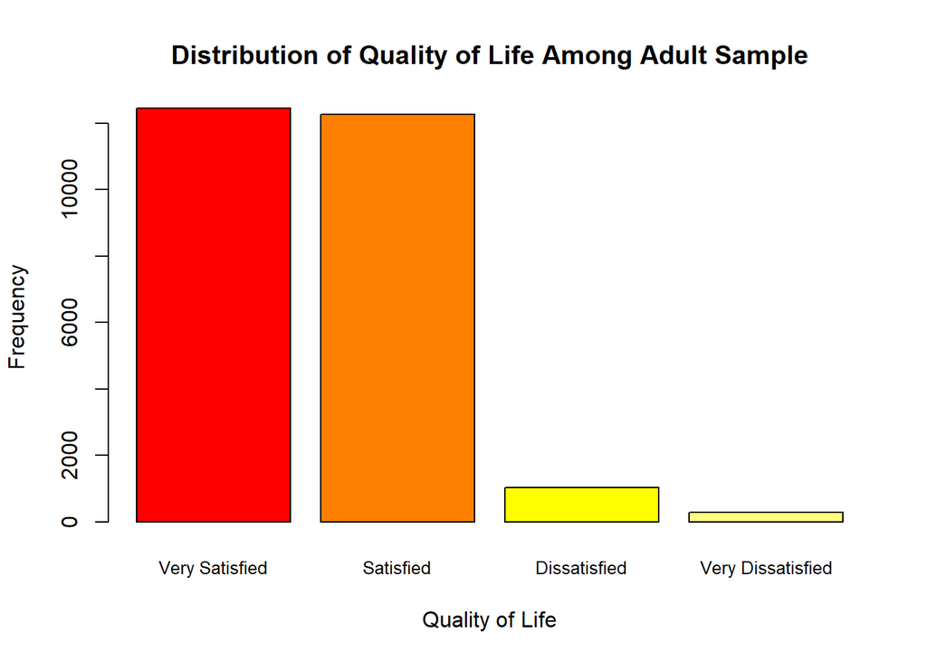

```r
barplot(lsatis4r_a_freq_table, #indicating r base barplot of lsatis4r_a variable through freq table
        main = "Distribution of Quality of Life Among Adult Sample", #chart title
        xlab = "Quality of Life", #x axis title
        ylab = "Frequency", #y axis title
        col = heat.colors(4), #bar plot colors
        cex.names = 0.8) #label size
```

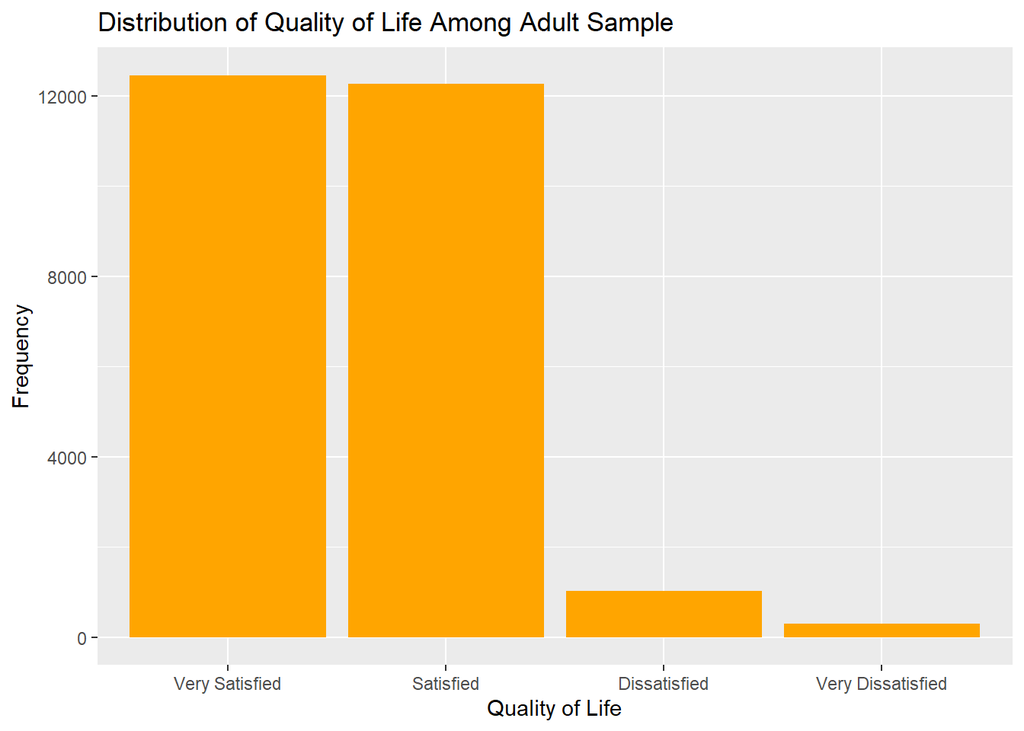

```r
lstatis4r_a_freq_df <- as.data.frame(lsatis4r_a_freq_table) #converting freq table to a data frame for ggplot

ggplot(lstatis4r_a_freq_df, aes(x=Var1,y=Freq)) + #using ggplot & the data frame, indicating x as the variables and y as the frequency
  geom_bar(stat = "identity",fill = "orange") + #indicating bar plot
  labs(title = "Distribution of Quality of Life Among Adult Sample", #chart title
       x = "Quality of Life", #x axis title
       y = "Frequency") #y axis title
```

Interpretation: The sample reports a high quality of life, with the majority of participants rating their lives as “very satisfied” or “satisfied.” Very few participants reported their lives as “dissatisfied” or “very dissatisfied.

## Bivariate Analysis

### **Age vs Sex Boxplots**

```r
# Day 3: Task 2: Bivariate Analysis (Boxplots Age v Sex & Age v Education)}

#Boxplot Age v Sex

"Age v Sex Boxplot"
```

```
## [1] "Age v Sex Boxplot"
```

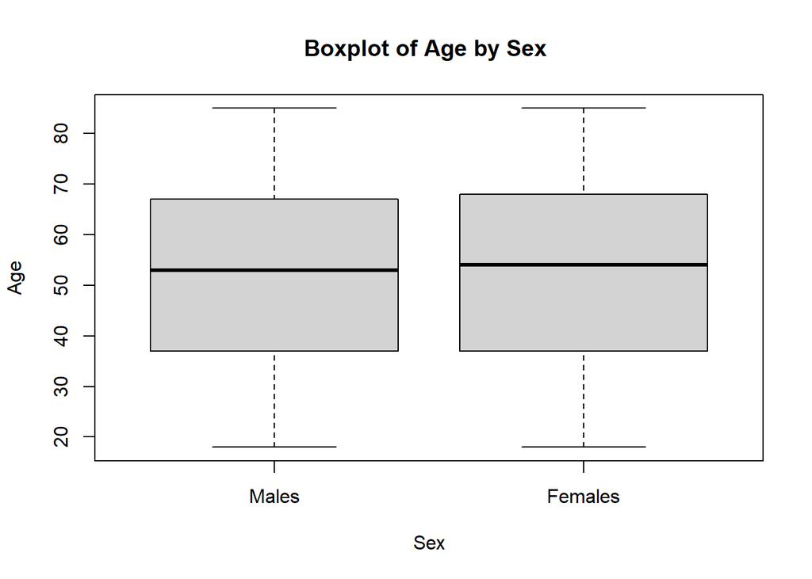

```r
boxplot(AGEP_A~SEX_A, data = nhis_clean,#boxplot
        main = "Boxplot of Age by Sex ", #chart title
        xlab = "Sex", #x axis title
        ylab = "Age") #y axis title
```

```r
"Age v Sex GGPlot"
```

```
## [1] "Age v Sex GGPlot"
```

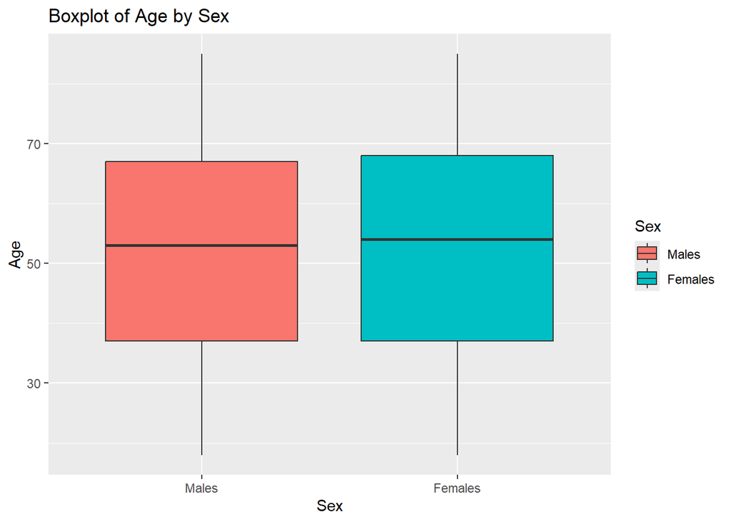

```r
ggplot(nhis_clean,aes(x=SEX_A,y=AGEP_A)) + #indicating gglot, data set, x & y axis
  geom_boxplot(aes(fill = factor(SEX_A))) + #identifying boxplot chart & filling box with Sex values
  labs(title = "Boxplot of Age by Sex", #chart title
       x = "Sex", #x axis title
       y = "Age", #y axis title
       fill = "Sex") #title of legend
```

Interpretation: Overall, both groups cover nearly the same age range, from slightly younger than 20 to the mid-80s. Additionally, both groups have very similar median ages, with females slightly higher; therefore, ~50 years of age is the typical age across the sexes. The distributions appear symmetrical and comparable. There is no strong skew, as there are no outliers or noticeable differences in variability between the two groups.

### **Age vs Education Boxplots**

```r
#Boxplot Age v Education

"Age v Education Boxplot"
```

```
## [1] "Age v Education Boxplot"
```

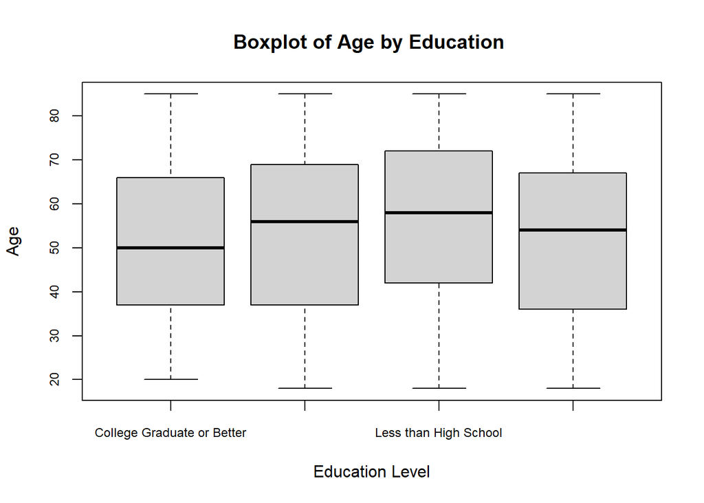

```r
boxplot(AGEP_A~EDUCP_A, data = nhis_clean,#boxplot
        main = "Boxplot of Age by Education ", #chart title
        xlab = "Education Level", #x axis title
        ylab = "Age",#y axis title
        cex.axis = 0.75) #size of x axis text
```

```r
"Age v Education ggplot"
```

```
## [1] "Age v Education ggplot"
```

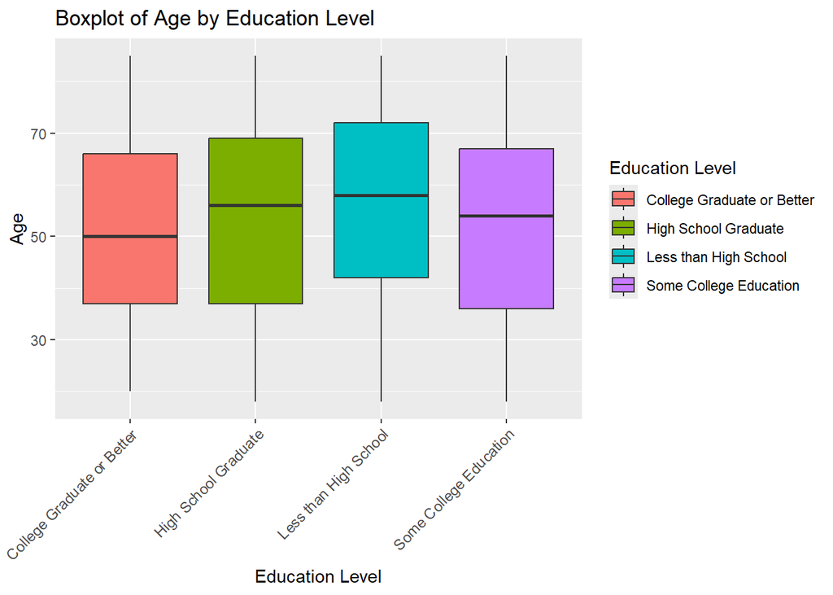

```r
ggplot(nhis_clean,aes(x=EDUCP_A,y=AGEP_A)) + #indicating gglot, data set, x & y axis
  geom_boxplot(aes(fill = factor(EDUCP_A))) + #identifying boxplot chart & filling box with Educ values
  labs(title = "Boxplot of Age by Education Level", #chart title
       x = "Education Level", #x axis title
       y = "Age", #y axis title
       fill = "Education Level") + #title of legend
  theme(axis.text.x = element_text(size = 9, angle = 45, hjust = 1)) #adjusts labels on x axis
```

### **General Health & Life Satisfaction Clustered Bar Chart**

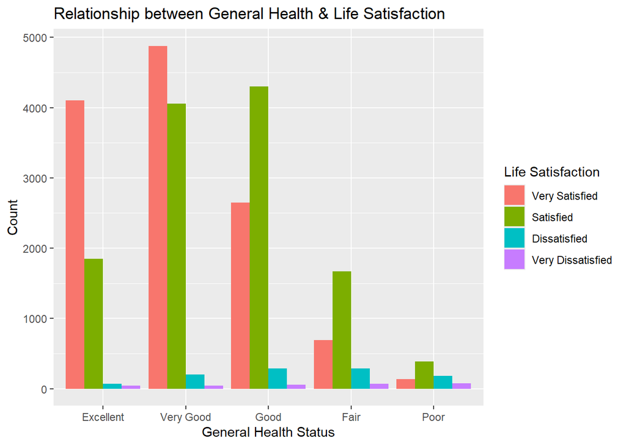

```r
#Clustered Bar Chart (General Health & Life Satisfaction)

ggplot(nhis_clean,aes(x=PHSTAT_A,fill = LSATIS4R_A)) + #identifying ggplot, x axis and y axis
  geom_bar(position = "dodge") + #indicating bar chart
  labs(title = "Relationship between General Health & Life Satisfaction", #chart title
       x = "General Health Status", #x axis title
       y = "Count", #y axis title
       fill = "Life Satisfaction") #legend title
```

Interpretation: As general health improves, life satisfaction tends to increase as well. People who reported “excellent” or “very good health” are much more likely to report being “very satisfied” with their lives. Participants who reported “fair” or “poor” health showed a sharp decline in the share, reporting “very satisfied,” suggesting that poorer health is strongly associated with lower life satisfaction. Interestingly, people with “good” health have the highest count of “satisfied” individuals, possibly reflecting that moderate health still allows a good degree of life satisfaction, though less enthusiasm than with “very good” or “excellent” health. Among those with “excellent” or “very good” health status, only a very small number reported being “dissatisfied” or “very dissatisfied”; this reinforces the pattern that good health contributes to positive life evaluations. Overall, the graph shows a clear, strong relationship between health and happiness because people who perceive their health as better tend to report higher life satisfaction. Conversely, as health status declines, life satisfaction drops correspondingly.

### **Height vs Weight Scatterplots**

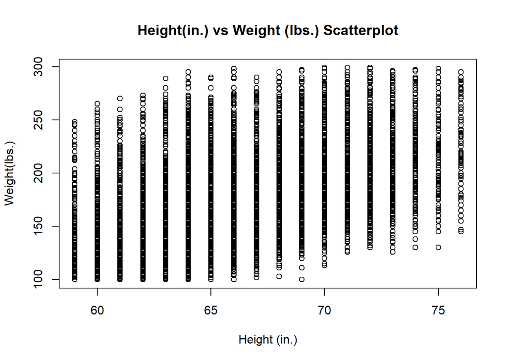

```r
#Scatterplot of Height vs Weight

plot(nhis_clean$HEIGHTTC_A,nhis_clean$WEIGHTLBTC_A, #scatterplot using plot() for height vs weight
     main = "Height(in.) vs Weight (lbs.) Scatterplot", #chart title
     xlab = "Height (in.)", #x axis title
     ylab = "Weight(lbs.)") #y axis title
```

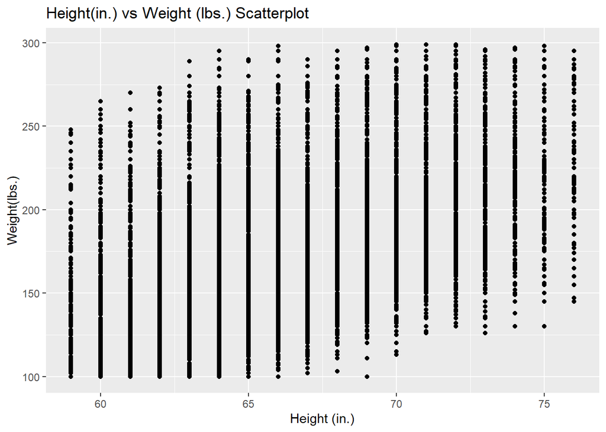

```r
ggplot(nhis_clean,aes(x=HEIGHTTC_A,y=WEIGHTLBTC_A)) + #using ggplot for scatterplot, indicating x and y values
  geom_point() + #indicating points for each observation
  labs(title = "Height(in.) vs Weight (lbs.) Scatterplot", #chart title
       x = "Height (in.)", #x axis title
       y = "Weight(lbs.)") #y axis title
```

```r
cor(nhis_clean$HEIGHTTC_A,nhis_clean$WEIGHTLBTC_A) #calculating & reporting correlation coefficient; results 0.5023, medium correlation
```

```
## [1] 0.5023037
```

Interpretation: The scatterplot shows heights ranging roughly from 58 to 76 inches and weights from 100 to 300 pounds. There is a positive association between height and weight, meaning that, on average, weight increases with height. This is supported by a correlation coefficient of 0.5023, indicating a moderate positive linear relationship, given the noticeable spread of weights at each height. This wide range suggests that height alone is not a precise predictor of weight and that other factors likely play a significant role in determining weight. The vertical stripes indicate that the height data is discrete rather than continuous. Furthermore, a few observations fall at the extreme high end of weight across multiple heights; although they do not disrupt the overall trend, they may warrant further investigation. Overall, while taller individuals generally weigh more, height alone is insufficient to accurately predict weight due to high variability.